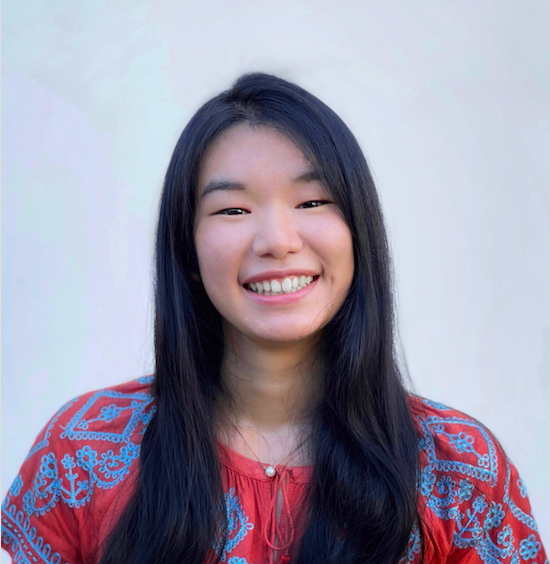

# Sita Lujintanon

## Bio 🧘🏻‍♀️

**Sita Lujintanon is an epidemiologic-implementation researcher.** Her research overall aims to **promote equity in HIV care engagement** through the use of implementation strategies and novel interventions (e.g., long-acting antiretroviral therapy). She has a growing interest in applying **observational-implementation research** approach for rapid knowledge generation to inform how to improve population health.

## Education 🎓

**PhD Student in Epidemiolgy** | Johns Hopkins School of Public Health | August 2023 - Present

**ScM in Epidemiolgy** | Johns Hopkins School of Public Health **|** August 2021 - May 2023

**BS in Biological Sciences** | Mahidol University International College **|** September 2016 - July 2019

## Experience 🌏

**Co-Founder & Co-President** | [Implementation Science Student Working Group](https://jhu.campusgroups.com/isswg/home/) | Johns Hopkins School of Public Health | August 2023 - Present

**Graduate Research Assistant** | [Implementation Science Core](https://hopkinscfar.org/science-cores/implementation-science-swg/) | [LIVE Project](https://live.idig.science/) | Johns Hopkins School of Public Health **|** October 2021 - Present

**Program Assistant** | [HIV Treatment Programs](https://ihri.org/hiv-treatment/) | Institute of HIV Research and Innovation **|** August 2019 - August 2021

**Student Intern** | Thai Red Cross AIDS Research Centre | August 2017 - August 2019

## Keywords ⚡️

HIV, Epidemiology, Implementation Science, Differentiated Service Delivery, Long-Acting Antiretroviral Therapy